# Covid91 vaccine study Final2021

Dom Ciriello

20210505

# 1 Introduction

A new preventative vaccine (covid91) is under test in clinical trials. Given the nature of this vaccine it is suspected that the drug may exhibit different effectiveness across the variety of subpopulations tracked. Consider population subgroups consisting of Males, Females, just the drug users, and just those in the LGBTQ community. Write a complete report that separately considers this drug for each subgroup and your recommendations as to whether people in the subgroup should take the vaccine. Structure your report in four sections each devoted to one of the four subgroups, use null and alternative hypothesis statements and correct statistical verbage when referencing p-values in conclusions.

# 2 Methods

The first step is isolating the 4 subgroups/sub-populations. After isolating 4 subgroups I will be evaluating the efficacy of the drug for each subgroup.

# 3 Males

```r
maledata<- filter(FinalData,sex=="guy")
maledata$sex <- as.factor(maledata$sex)
```

## 3.1 Bar Chart

```r
Males <- maledata %>% group_by(infected, treatment) %>% summarize(count=n()) %>% mutate(prcnt=count/sum(count))
```

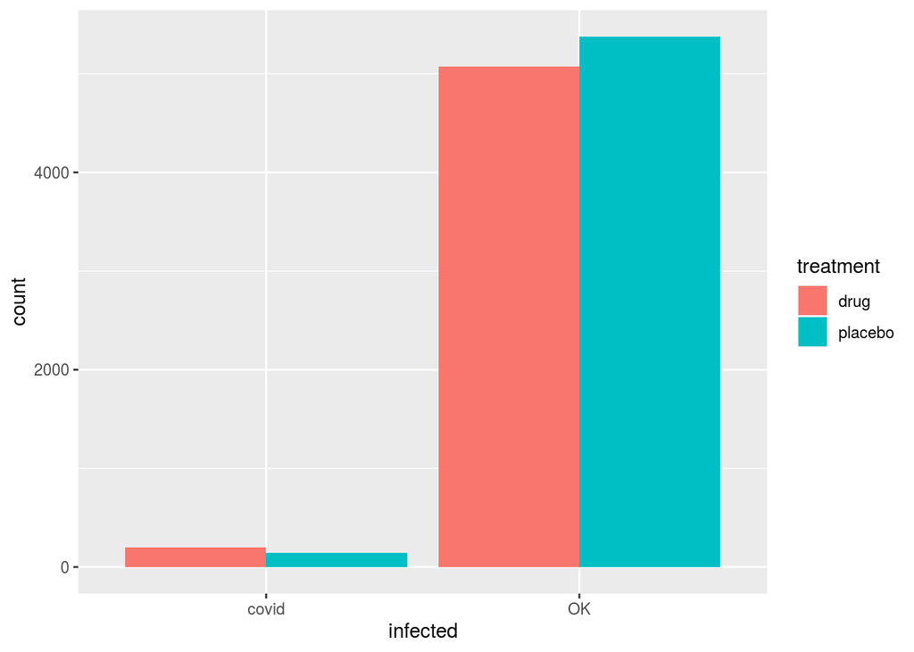

```r
# the group_by followed by summarize(count=n())

basicC <- ggplot(Males,aes(x=infected,y=count,fill=treatment))
basicC + geom_bar(stat="identity",position="dodge")
```

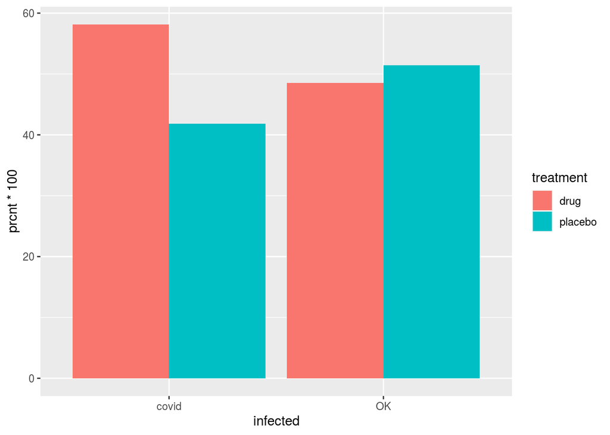

```r
#Now for percentage plot

basicCC <- ggplot(Males,aes(x=infected,y=prcnt*100,fill=treatment))
basicCC + geom_bar(stat="identity", position = "dodge")
```

This barchart shows that 58% of the infected males were given the drug and 42% were given the placebo.

## 3.2 Numerical Summary

```r
table1 <- xtabs(~treatment + infected, data=maledata)
rowPerc(table1)
```

```
##          infected
## treatment  covid     OK  Total
##   drug      3.72  96.28 100.00
##   placebo   2.55  97.45 100.00
```

```r
colPerc(table1)
```

```
##          infected
## treatment  covid     OK
##   drug     58.16  48.54
##   placebo  41.84  51.46
##   Total   100.00 100.00
```

```r
print(table1)
```

```
##          infected
## treatment covid   OK
##   drug      196 5072
##   placebo   141 5378
```

## 3.3 Inferential Results

```r
chisq.test(table1)
```

```
##
##  Pearson's Chi-squared test with Yates' continuity correction
##
## data:  table1
## X-squared = 11.721, df = 1, p-value = 0.0006181
```

```r
chisqtestGC(table1)
```

```
## Pearson's Chi-squared test with Yates' continuity correction
##
## Observed Counts:
##          infected
## treatment covid   OK
##   drug      196 5072
##   placebo   141 5378
##
## Counts Expected by Null:
##          infected
## treatment  covid      OK
##   drug    164.58 5103.42
##   placebo 172.42 5346.58
##
## Contributions to the chi-square statistic:
##          infected
## treatment covid   OK
##   drug     6.00 0.19
##   placebo  5.73 0.18
##
##
## Chi-Square Statistic = 11.7206
## Degrees of Freedom of the table = 1
## P-Value = 6e-04
```

```r
fisher.test(table1)
```

```
##
##  Fisher's Exact Test for Count Data
##
## data:  table1
## p-value = 0.0005801
## alternative hypothesis: true odds ratio is not equal to 1
## 95 percent confidence interval:
##  1.176773 1.849769
## sample estimates:
## odds ratio
##   1.473872
```

Since the p-value is extremely small, the odds of our results happening purely by chance is extremely unlikely.

$H_0$  
The null hypothesis is that this vaccine makes no difference in whether or not you contract COVID for males.

$H_A$  
The alternative hypothesis is that the vaccine does make a difference for males in whether or not they contract COVID.

Therefore we reject the null hypothesis since there is a clear difference in the number of infected people who did or did not take the drug.

By converting our odds ratios into an effectiveness percentage, we can see that the drug is 40% effective for men. Since it is below 50% this means that it is actually ineffective for the male subgroup.

# 4 Females

```r
femaledata<- filter(FinalData,sex=="gal")
femaledata$sex <- as.factor(femaledata$sex)
```

## 4.1 Bar Chart

```r
Females <- femaledata %>% group_by(infected, treatment) %>% summarize(count=n()) %>% mutate(prcnt=count/sum(count))
```

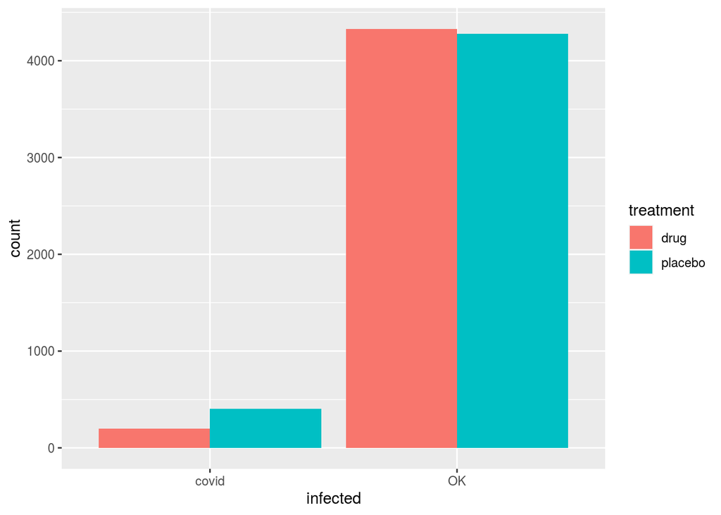

```r
# the group_by followed by summarize(count=n())

basicC <- ggplot(Females,aes(x=infected,y=count,fill=treatment))
basicC + geom_bar(stat="identity",position="dodge")
```

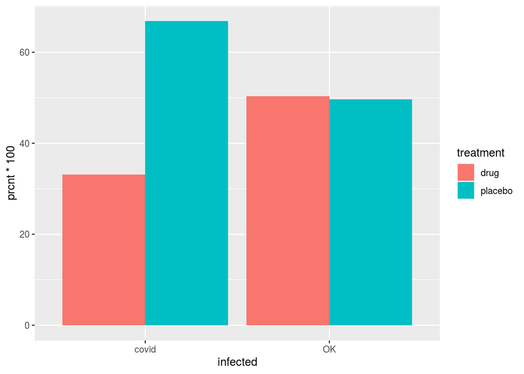

```r
#Now for percentage plot

basicCC <- ggplot(Females,aes(x=infected,y=prcnt*100,fill=treatment))
basicCC + geom_bar(stat="identity", position = "dodge")
```

This barchart shows that 67% of the infected females were given the placebo and 33% were given the drug.

## 4.2 Numerical Summary

```r
table2 <- xtabs(~infected + treatment, data=femaledata)
rowPerc(table2)
```

```
##         treatment
## infected   drug placebo  Total
##    covid  33.11   66.89 100.00
##    OK     50.31   49.69 100.00
```

```r
colPerc(table2)
```

```
##         treatment
## infected   drug placebo
##    covid   4.44    8.67
##    OK     95.56   91.33
##    Total 100.00  100.00
```

```r
print(table2)
```

```
##         treatment
## infected drug placebo
##    covid  201     406
##    OK    4330    4276
```

Based on the numerical summary, 607 of the 9,213 females in the study were infected with COVID. Of those 607, 406 had received the placebo and only 201 received the drug. The table shows that 4.44% of the females who received the drug contracted COVID while 8.67% of the females who received the placebo contracted COVID.

## 4.3 Inferential Results

```r
chisq.test(table2)
```

```
##
##  Pearson's Chi-squared test with Yates' continuity correction
##
## data:  table2
## X-squared = 66.43, df = 1, p-value = 3.626e-16
```

```r
chisqtestGC(table2)
```

```
## Pearson's Chi-squared test with Yates' continuity correction
##
## Observed Counts:
##         treatment
## infected drug placebo
##    covid  201     406
##    OK    4330    4276
##
## Counts Expected by Null:
##         treatment
## infected    drug placebo
##    covid  298.53  308.47
##    OK    4232.47 4373.53
##
## Contributions to the chi-square statistic:
##         treatment
## infected  drug placebo
##    covid 31.86   30.83
##    OK     2.25    2.17
##
##
## Chi-Square Statistic = 66.4295
## Degrees of Freedom of the table = 1
## P-Value = 0
```

```r
fisher.test(table2)
```

```
##
##  Fisher's Exact Test for Count Data
##
## data:  table2
## p-value < 2.2e-16
## alternative hypothesis: true odds ratio is not equal to 1
## 95 percent confidence interval:
##  0.4086458 0.5836109
## sample estimates:
## odds ratio
##  0.4889403
```

Since the p-value is extremely small, the odds of our results happening purely by chance is extremely unlikely.

$H_0$  
The null hypothesis is that this vaccine makes no difference in whether or not you contract COVID for females.

$H_A$  
The alternative hypothesis is that the vaccine does make a difference for females in whether or not they contract COVID.

Therefore we reject the null hypothesis since there is a clear difference in the number of infected people who did or did not take the drug.

By converting our odds ratios into an effectiveness percentage, we can see that the drug is 67% effective for females.

# 5 LGBTQ (Gay)

```r
LGBTQdata<- filter(FinalData,LGBTQ=="gay")
LGBTQdata$sex <- as.factor(LGBTQdata$LGBTQ)
```

## 5.1 Bar Chart

```r
Gays <- LGBTQdata %>% group_by(infected, treatment) %>% summarize(count=n()) %>% mutate(prcnt=count/sum(count))
```

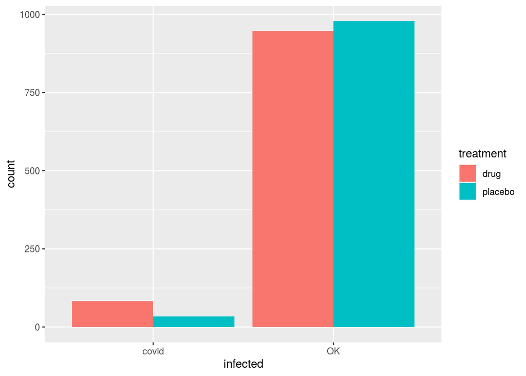

```r
# the group_by followed by summarize(count=n())

basicC <- ggplot(Gays,aes(x=infected,y=count,fill=treatment))
basicC + geom_bar(stat="identity",position="dodge")
```

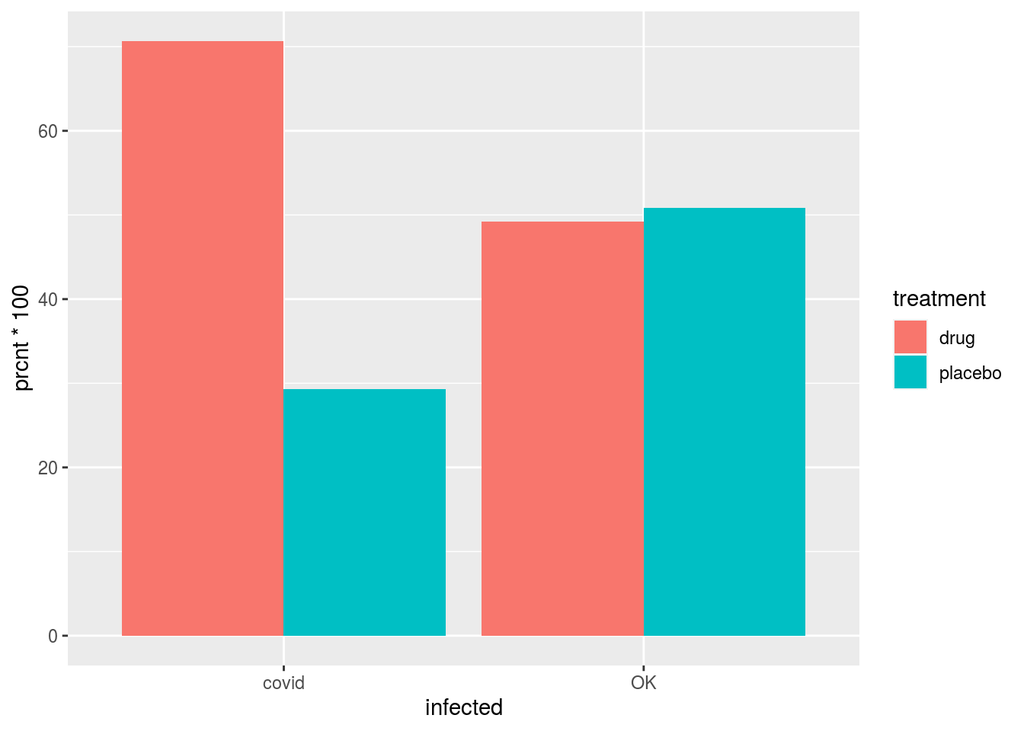

```r
#Now for percentage plot

basicCC <- ggplot(Gays,aes(x=infected,y=prcnt*100,fill=treatment))
basicCC + geom_bar(stat="identity", position = "dodge")
```

This barchart shows that 71% of the infected gay people among the LGBTQ community were given the drug and 29% were given the placebo.

## 5.2 Numerical Summary

```r
table3 <- xtabs(~treatment + infected, data=LGBTQdata)
rowPerc(table3)
```

```
##          infected
## treatment  covid     OK  Total
##   drug      7.97  92.03 100.00
##   placebo   3.36  96.64 100.00
```

```r
colPerc(table3)
```

```
##          infected
## treatment  covid     OK
##   drug     70.69  49.17
##   placebo  29.31  50.83
##   Total   100.00 100.00
```

```r
print(table3)
```

```
##          infected
## treatment covid  OK
##   drug       82 947
##   placebo    34 979
```

Based on the numerical summary, 116 of the 2,042 gay people in the study were infected with COVID. Out of those 116, 82 had received the drug and only 34 received the placebo. The table shows that 7.97% of the people who received the drug contracted COVID while 3.36% of the people who received the placebo contracted COVID.

## 5.3 Inferential Results

```r
chisq.test(table3)
```

```
##
##  Pearson's Chi-squared test with Yates' continuity correction
##
## data:  table3
## X-squared = 19.418, df = 1, p-value = 1.05e-05
```

```r
chisqtestGC(table3)
```

```
## Pearson's Chi-squared test with Yates' continuity correction
##
## Observed Counts:
##          infected
## treatment covid  OK
##   drug       82 947
##   placebo    34 979
##
## Counts Expected by Null:
##          infected
## treatment covid     OK
##   drug    58.45 970.55
##   placebo 57.55 955.45
##
## Contributions to the chi-square statistic:
##          infected
## treatment covid   OK
##   drug     9.48 0.57
##   placebo  9.63 0.58
##
##
## Chi-Square Statistic = 19.4179
## Degrees of Freedom of the table = 1
## P-Value = 0
```

```r
fisher.test(table3)
```

```
##
##  Fisher's Exact Test for Count Data
##
## data:  table3
## p-value = 5.741e-06
## alternative hypothesis: true odds ratio is not equal to 1
## 95 percent confidence interval:
##  1.633701 3.874869
## sample estimates:
## odds ratio
##   2.492206
```

Since the p-value is extremely small, the odds of our results happening purely by chance is extremely unlikely.

$H_0$  
The null hypothesis is that this vaccine makes no difference in whether or not you contract COVID for the LGBTQ community.

$H_A$  
The alternative hypothesis is that the vaccine does make a difference for the LGBTQ community in whether or not they contract COVID.

Therefore we reject the null hypothesis since there is a clear difference in the number of infected people who did or did not take the drug.

By converting our odds ratios into an effectiveness percentage, we can see that the drug is 28% effective for gay people. Since it is below 50% this means that it is actually ineffective for the LGBTQ subgroup.

# 6 Drug Users

```r
DrugUserdata<- filter(FinalData,DrugUser=="yes")
DrugUserdata$DrugUser <- as.factor(DrugUserdata$DrugUser)
```

## 6.1 Bar Chart

```r
Users <- DrugUserdata %>% group_by(infected, treatment) %>% summarize(count=n()) %>% mutate(prcnt=count/sum(count))
```

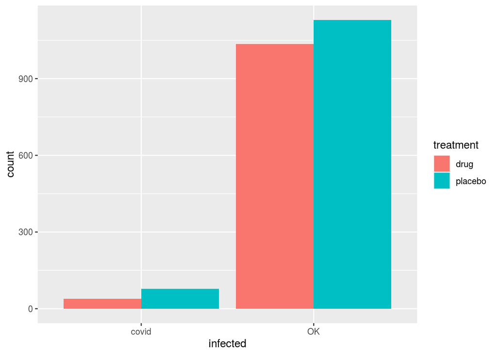

```r
# the group_by followed by summarize(count=n())

basicC <- ggplot(Users,aes(x=infected,y=count,fill=treatment))
basicC + geom_bar(stat="identity",position="dodge")
```

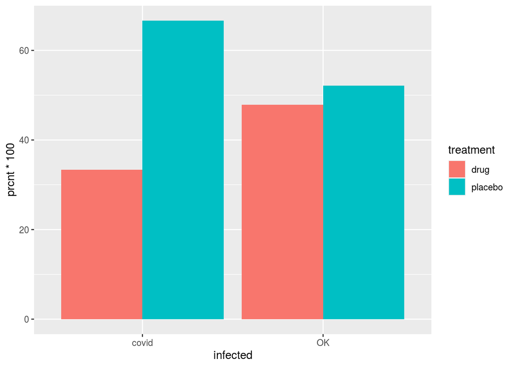

```r
#Now for percentage plot

basicCC <- ggplot(Users,aes(x=infected,y=prcnt*100,fill=treatment))
basicCC + geom_bar(stat="identity", position = "dodge")
```

This barchart shows that 67% of the infected drug users were given the placebo and 33% were given the drug.

## 6.2 Numerical Summary

```r
table4 <- xtabs(~treatment + infected, data=DrugUserdata)
rowPerc(table4)
```

```
##          infected
## treatment  covid     OK  Total
##   drug      3.63  96.37 100.00
##   placebo   6.46  93.54 100.00
```

```r
colPerc(table4)
```

```
##          infected
## treatment  covid     OK
##   drug     33.33  47.83
##   placebo  66.67  52.17
##   Total   100.00 100.00
```

```r
print(table4)
```

```
##          infected
## treatment covid   OK
##   drug       39 1036
##   placebo    78 1130
```

## 6.3 Inferential Results

```r
chisq.test(table4)
```

```
##
##  Pearson's Chi-squared test with Yates' continuity correction
##
## data:  table4
## X-squared = 8.7902, df = 1, p-value = 0.003028
```

```r
chisqtestGC(table4)
```

```
## Pearson's Chi-squared test with Yates' continuity correction
##
## Observed Counts:
##          infected
## treatment covid   OK
##   drug       39 1036
##   placebo    78 1130
##
## Counts Expected by Null:
##          infected
## treatment covid      OK
##   drug    55.09 1019.91
##   placebo 61.91 1146.09
##
## Contributions to the chi-square statistic:
##          infected
## treatment covid   OK
##   drug     4.70 0.25
##   placebo  4.18 0.23
##
##
## Chi-Square Statistic = 8.7902
## Degrees of Freedom of the table = 1
## P-Value = 0.003
```

```r
fisher.test(table4)
```

```
##
##  Fisher's Exact Test for Count Data
##
## data:  table4
## p-value = 0.002273
## alternative hypothesis: true odds ratio is not equal to 1
## 95 percent confidence interval:
##  0.3580726 0.8194461
## sample estimates:
## odds ratio
##  0.5455093
```

Since the p-value is extremely small, the odds of our results happening purely by chance is extremely unlikely.

$H_0$  
The null hypothesis is that this vaccine makes no difference in whether or not you contract COVID for drug users.

$H_A$  
The alternative hypothesis is that the vaccine does make a difference for drug users in whether or not they contract COVID.

Therefore we reject the null hypothesis since there is a clear difference in the number of infected people who did or did not take the drug.

By converting our odds ratios into an effectiveness percentage, we can see that the drug is 65% effective for drug users.

# 7 Discussion & Conclusion

There were clear differences in the number of infected people based on whether or not they took the drug. The males and gay people actually became more susceptible to contracting COVID after taking the drug (the gay people especially). The drug did seem slightly effective for the females and drug users. However for all 4, there was a clear difference between taking and not taking the drug which led me to reject the null hypothesis.

Also, none of the 4 effectiveness percentages were very high. The highest effectiveness among the 4 subgroups was only 67% (for females). The second highest was for drug users at 65%, third was males at 40% and lastly it was only 28% effective for the LGBTQ community. Since there are both males AND females in the LGBTQ community, these numbers do raise doubts and serious concerns about the overall effectiveness (ineffectiveness) for humans overall.